# VisitorsTSAnalysis

Sandhya Amaresh

July 20, 2016

## R Markdown

#### This is a R Markdown file to plot the TS for the Visitors dataset

#### Plot the time series. Can you identify seasonal fluctuations and/or a trend?

```r
library(fpp)
```

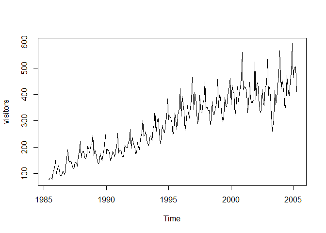

```r
data("visitors")
plot(visitors)
```

#### Observation - we see an upward trend in the visitors, with seasonsal fluctuations, so the visitors ####increases in summer months and dip in winter months

#### Use a classical decomposition to calculate the trend-cycle and seasonal indices.

#### Do the results support the graphical interpretation from part (a)?

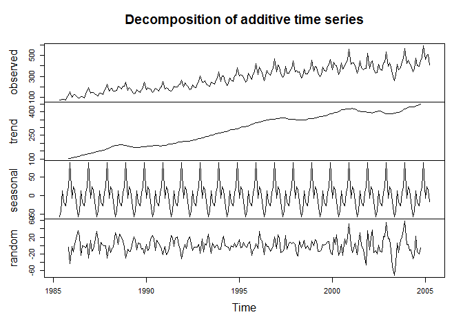

```r
fitd <- decompose(visitors)
plot(fitd)
```

#### Compute and plot the seasonally adjusted data.

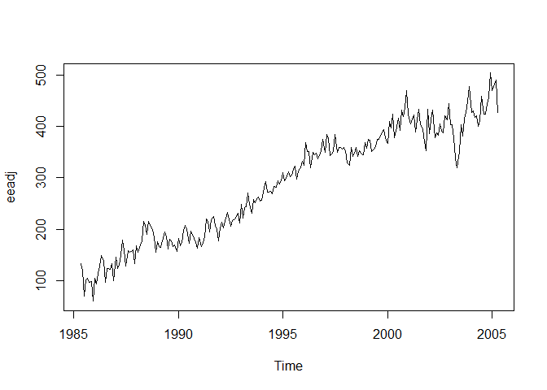

```r
eeadj <- seasadj(fitd)
plot(eeadj)
```

#### Change one observation to be an outlier (e.g., add 500 to one observation), and recompute the seasonally adjusted data. What is the effect of the outlier?

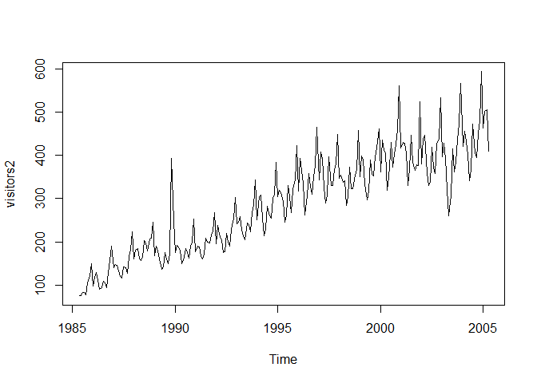

```r
visitors2 <- ts(c(visitors[1:54],visitors[55]+200,visitors[56:240]),start=c(1985,5),frequency=12)
plot(visitors2)
```

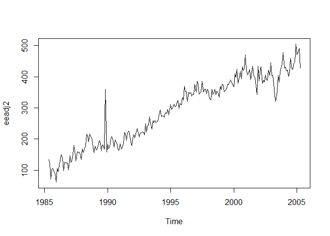

```r
fitd2 <- decompose(visitors2)
eeadj2 <- seasadj(fitd2)
plot(eeadj2)
```

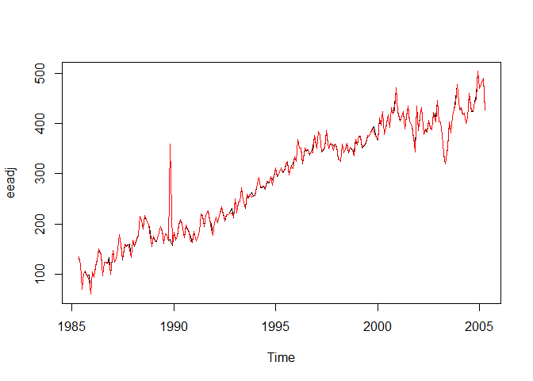

```r
plot(eeadj)
lines(eeadj2,type="l",col="red")
```

#### Does it make any difference if the outlier is near the end rather than in the middle of the time series?

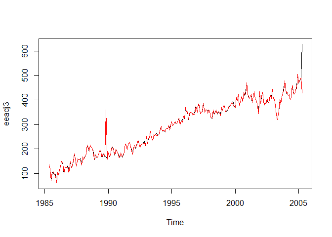

```r
visitors3 <- ts(c(visitors[1:239],visitors[240]+200),start=c(1985,5),frequency=12)
fitd3 <- decompose(visitors3)
eeadj3 <- seasadj(fitd3)
plot(eeadj3)
lines(eeadj2,type="l",col="red")
```

####The outlier in the end is plotted in black and the outlier in middle is plotted in red, we see that there ####is not much difference, except there is an increase in the middle in the 1st scenario and increase in the ####end in the 2nd scenario

#### Now use STL to decompose the series.

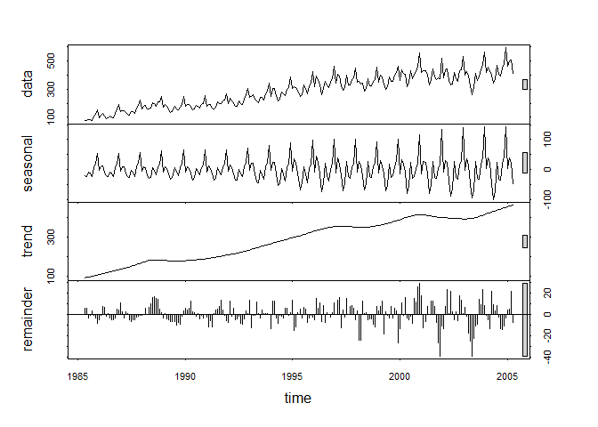

```r
fit <- stl(visitors, s.window=5)
plot(fit)
```

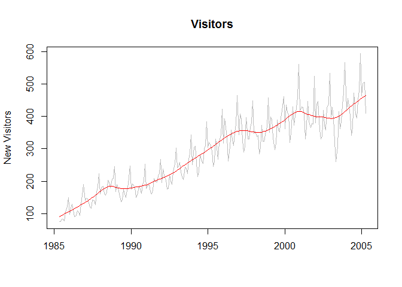

```r
plot(visitors, col="gray",
      main="Visitors",
      ylab="New Visitors", xlab="")
lines(fit$time.series[,2],col="red",ylab="Trend")
```